# Explore Movie Dataset

## 探索电影数据集

在这个项目中，你将尝试使用所学的知识，使用 `NumPy`、`Pandas`、`matplotlib`、`seaborn` 库中的函数，来对电影数据集进行探索。

下载数据集： [TMDb电影数据](https://s3.cn-north-1.amazonaws.com.cn/static-documents/nd101/explore+dataset/tmdb-movies.csv)

数据集各列名称的含义：

| 列名称 | id | imdb_id | popularity | budget | revenue | original_title | cast | homepage | director | tagline | keywords | overview | runtime | genres | production_companies | release_date | vote_count | vote_average | release_year | budget_adj | revenue_adj |
| --- | --- | --- | --- | --- | --- | --- | --- | --- | --- | --- | --- | --- | --- | --- | --- | --- | --- | --- | --- | --- | --- |
| 含义 | 编号 | IMDB 编号 | 知名度 | 预算 | 票房 | 名称 | 主演 | 网站 | 导演 | 宣传词 | 关键词 | 简介 | 时常 | 类别 | 发行公司 | 发行日期 | 投票总数 | 投票均值 | 发行年份 | 预算（调整后） | 票房（调整后） |

**请注意，你需要提交该报告导出的 `.html`、`.ipynb` 以及 `.py` 文件。**

## 第一节 数据的导入与处理

在这一部分，你需要编写代码，使用 Pandas 读取数据，并进行预处理。

**任务1.1：** 导入库以及数据

1. 载入需要的库 `NumPy`、`Pandas`、`matplotlib`、`seaborn`。
2. 利用 `Pandas` 库，读取 `tmdb-movies.csv` 中的数据，保存为 `movie_data`。

提示：记得使用 notebook 中的魔法指令 `%matplotlib inline`，否则会导致你接下来无法打印出图像。

```python
import numpy as np
import pandas as pd
import matplotlib.pyplot as plt
import seaborn as sb
%matplotlib inline
movie_data = pd.read_csv('tmdb-movies.csv')
```

**任务1.2:** 了解数据

你会接触到各种各样的数据表，因此在读取之后，我们有必要通过一些简单的方法，来了解我们数据表是什么样子的。

1. 获取数据表的行列，并打印。
2. 使用 `.head()`、`.tail()`、`.sample()` 方法，观察、了解数据表的情况。
3. 使用 `.dtypes` 属性，来查看各列数据的数据类型。
4. 使用 `isnull()` 配合 `.any()` 等方法，来查看各列是否存在空值。
5. 使用 `.describe()` 方法，看看数据表中数值型的数据是怎么分布的。

```python
movie_data.shape
```

```
(10866, 21)
```

```python
movie_data.head()
```

|  | id | imdb_id | popularity | budget | revenue | original_title | cast | homepage | director | tagline | ... | overview | runtime | genres | production_companies | release_date | vote_count | vote_average | release_year | budget_adj | revenue_adj |
| --- | --- | --- | --- | --- | --- | --- | --- | --- | --- | --- | --- | --- | --- | --- | --- | --- | --- | --- | --- | --- | --- |
| 0 | 135397 | tt0369610 | 32.985763 | 150000000 | 1513528810 | Jurassic World | Chris Pratt\|Bryce Dallas Howard\|Irrfan Khan\|Vi... | http://www.jurassicworld.com/ | Colin Trevorrow | The park is open. | ... | Twenty-two years after the events of Jurassic ... | 124 | Action\|Adventure\|Science Fiction\|Thriller | Universal Studios\|Amblin Entertainment\|Legenda... | 6/9/15 | 5562 | 6.5 | 2015 | 1.379999e+08 | 1.392446e+09 |
| 1 | 76341 | tt1392190 | 28.419936 | 150000000 | 378436354 | Mad Max: Fury Road | Tom Hardy\|Charlize Theron\|Hugh Keays-Byrne\|Nic... | http://www.madmaxmovie.com/ | George Miller | What a Lovely Day. | ... | An apocalyptic story set in the furthest reach... | 120 | Action\|Adventure\|Science Fiction\|Thriller | Village Roadshow Pictures\|Kennedy Miller Produ... | 5/13/15 | 6185 | 7.1 | 2015 | 1.379999e+08 | 3.481613e+08 |
| 2 | 262500 | tt2908446 | 13.112507 | 110000000 | 295238201 | Insurgent | Shailene Woodley\|Theo James\|Kate Winslet\|Ansel... | http://www.thedivergentseries.movie/#insurgent | Robert Schwentke | One Choice Can Destroy You | ... | Beatrice Prior must confront her inner demons ... | 119 | Adventure\|Science Fiction\|Thriller | Summit Entertainment\|Mandeville Films\|Red Wago... | 3/18/15 | 2480 | 6.3 | 2015 | 1.012000e+08 | 2.716190e+08 |
| 3 | 140607 | tt2488496 | 11.173104 | 200000000 | 2068178225 | Star Wars: The Force Awakens | Harrison Ford\|Mark Hamill\|Carrie Fisher\|Adam D... | http://www.starwars.com/films/star-wars-episod... | J.J. Abrams | Every generation has a story. | ... | Thirty years after defeating the Galactic Empi... | 136 | Action\|Adventure\|Science Fiction\|Fantasy | Lucasfilm\|Truenorth Productions\|Bad Robot | 12/15/15 | 5292 | 7.5 | 2015 | 1.839999e+08 | 1.902723e+09 |
| 4 | 168259 | tt2820852 | 9.335014 | 190000000 | 1506249360 | Furious 7 | Vin Diesel\|Paul Walker\|Jason Statham\|Michelle ... | http://www.furious7.com/ | James Wan | Vengeance Hits Home | ... | Deckard Shaw seeks revenge against Dominic Tor... | 137 | Action\|Crime\|Thriller | Universal Pictures\|Original Film\|Media Rights ... | 4/1/15 | 2947 | 7.3 | 2015 | 1.747999e+08 | 1.385749e+09 |

5 rows × 21 columns

```python
movie_data.tail()
```

|  | id | imdb_id | popularity | budget | revenue | original_title | cast | homepage | director | tagline | ... | overview | runtime | genres | production_companies | release_date | vote_count | vote_average | release_year | budget_adj | revenue_adj |
| --- | --- | --- | --- | --- | --- | --- | --- | --- | --- | --- | --- | --- | --- | --- | --- | --- | --- | --- | --- | --- | --- |
| 10861 | 21 | tt0060371 | 0.080598 | 0 | 0 | The Endless Summer | Michael Hynson\|Robert August\|Lord 'Tally Ho' B... | NaN | Bruce Brown | NaN | ... | The Endless Summer, by Bruce Brown, is one of ... | 95 | Documentary | Bruce Brown Films | 6/15/66 | 11 | 7.4 | 1966 | 0.000000 | 0.0 |
| 10862 | 20379 | tt0060472 | 0.065543 | 0 | 0 | Grand Prix | James Garner\|Eva Marie Saint\|Yves Montand\|Tosh... | NaN | John Frankenheimer | Cinerama sweeps YOU into a drama of speed and ... | ... | Grand Prix driver Pete Aron is fired by his te... | 176 | Action\|Adventure\|Drama | Cherokee Productions\|Joel Productions\|Douglas ... | 12/21/66 | 20 | 5.7 | 1966 | 0.000000 | 0.0 |
| 10863 | 39768 | tt0060161 | 0.065141 | 0 | 0 | Beregis Avtomobilya | Innokentiy Smoktunovskiy\|Oleg Efremov\|Georgi Z... | NaN | Eldar Ryazanov | NaN | ... | An insurance agent who moonlights as a carthie... | 94 | Mystery\|Comedy | Mosfilm | 1/1/66 | 11 | 6.5 | 1966 | 0.000000 | 0.0 |
| 10864 | 21449 | tt0061177 | 0.064317 | 0 | 0 | What's Up, Tiger Lily? | Tatsuya Mihashi\|Akiko Wakabayashi\|Mie Hama\|Joh... | NaN | Woody Allen | WOODY ALLEN STRIKES BACK! | ... | In comic Woody Allen's film debut, he took the... | 80 | Action\|Comedy | Benedict Pictures Corp. | 11/2/66 | 22 | 5.4 | 1966 | 0.000000 | 0.0 |
| 10865 | 22293 | tt0060666 | 0.035919 | 19000 | 0 | Manos: The Hands of Fate | Harold P. Warren\|Tom Neyman\|John Reynolds\|Dian... | NaN | Harold P. Warren | It's Shocking! It's Beyond Your Imagination! | ... | A family gets lost on the road and stumbles up... | 74 | Horror | Norm-Iris | 11/15/66 | 15 | 1.5 | 1966 | 127642.279154 | 0.0 |

5 rows × 21 columns

```python
movie_data.sample()
```

|  | id | imdb_id | popularity | budget | revenue | original_title | cast | homepage | director | tagline | ... | overview | runtime | genres | production_companies | release_date | vote_count | vote_average | release_year | budget_adj | revenue_adj |
| --- | --- | --- | --- | --- | --- | --- | --- | --- | --- | --- | --- | --- | --- | --- | --- | --- | --- | --- | --- | --- | --- |
| 7000 | 10096 | tt0337563 | 1.497252 | 37000000 | 96455697 | 13 Going On 30 | Jennifer Garner\|Mark Ruffalo\|Judy Greer\|Andy S... | NaN | Gary Winick | For some, 13 feels like it was just yesterday.... | ... | After total humiliation at her thirteenth birt... | 98 | Comedy\|Fantasy\|Romance | Columbia Pictures\|Revolution Studios\|Thirteen ... | 4/13/04 | 662 | 6.1 | 2004 | 4.271448e+07 | 1.113528e+08 |

1 rows × 21 columns

```python
movie_data.dtypes
```

```
id                        int64
imdb_id                  object
popularity              float64
budget                    int64
revenue                   int64
original_title           object
cast                     object
homepage                 object
director                 object
tagline                  object
keywords                 object
overview                 object
runtime                   int64
genres                   object
production_companies     object
release_date             object
vote_count                int64
vote_average            float64
release_year              int64
budget_adj              float64
revenue_adj             float64
dtype: object
```

```python
movie_data.isnull().sum(axis=0)
```

```
id                         0
imdb_id                   10
popularity                 0
budget                     0
revenue                    0
original_title             0
cast                      76
homepage                7930
director                  44
tagline                 2824
keywords                1493
overview                   4
runtime                    0
genres                    23
production_companies    1030
release_date               0
vote_count                 0
vote_average               0
release_year               0
budget_adj                 0
revenue_adj                0
dtype: int64
```

```python
movie_data.isnull().any(axis=0)
```

```
id                      False
imdb_id                  True
popularity              False
budget                  False
revenue                 False
original_title          False
cast                     True
homepage                 True
director                 True
tagline                  True
keywords                 True
overview                 True
runtime                 False
genres                   True
production_companies     True
release_date            False
vote_count              False
vote_average            False
release_year            False
budget_adj              False
revenue_adj             False
dtype: bool
```

```python
movie_data.describe()
```

|  | id | popularity | budget | revenue | runtime | vote_count | vote_average | release_year | budget_adj | revenue_adj |
| --- | --- | --- | --- | --- | --- | --- | --- | --- | --- | --- |
| count | 10866.000000 | 10866.000000 | 1.086600e+04 | 1.086600e+04 | 10866.000000 | 10866.000000 | 10866.000000 | 10866.000000 | 1.086600e+04 | 1.086600e+04 |
| mean | 66064.177434 | 0.646441 | 1.462570e+07 | 3.982332e+07 | 102.070863 | 217.389748 | 5.974922 | 2001.322658 | 1.755104e+07 | 5.136436e+07 |
| std | 92130.136561 | 1.000185 | 3.091321e+07 | 1.170035e+08 | 31.381405 | 575.619058 | 0.935142 | 12.812941 | 3.430616e+07 | 1.446325e+08 |
| min | 5.000000 | 0.000065 | 0.000000e+00 | 0.000000e+00 | 0.000000 | 10.000000 | 1.500000 | 1960.000000 | 0.000000e+00 | 0.000000e+00 |
| 25% | 10596.250000 | 0.207583 | 0.000000e+00 | 0.000000e+00 | 90.000000 | 17.000000 | 5.400000 | 1995.000000 | 0.000000e+00 | 0.000000e+00 |
| 50% | 20669.000000 | 0.383856 | 0.000000e+00 | 0.000000e+00 | 99.000000 | 38.000000 | 6.000000 | 2006.000000 | 0.000000e+00 | 0.000000e+00 |
| 75% | 75610.000000 | 0.713817 | 1.500000e+07 | 2.400000e+07 | 111.000000 | 145.750000 | 6.600000 | 2011.000000 | 2.085325e+07 | 3.369710e+07 |
| max | 417859.000000 | 32.985763 | 4.250000e+08 | 2.781506e+09 | 900.000000 | 9767.000000 | 9.200000 | 2015.000000 | 4.250000e+08 | 2.827124e+09 |

**任务1.3:** 清理数据

在真实的工作场景中，数据处理往往是最为费时费力的环节。但是幸运的是，我们提供给大家的 tmdb 数据集非常的「干净」，不需要大家做特别多的数据清洗以及处理工作。在这一步中，你的核心的工作主要是对数据表中的空值进行处理。你可以使用 `.fillna()` 来填补空值，当然也可以使用 `.dropna()` 来丢弃数据表中包含空值的某些行或者列。

任务：使用适当的方法来清理空值，并将得到的数据保存。

```python
# 删除无用的列
movie_data_drop = movie_data.drop(['imdb_id', 'cast', 'homepage', 'tagline', 'keywords', 'overview', 'production_companies'], axis=1)
# 删除含有空值的行
movie_data_drop.dropna(inplace=True)
movie_data_drop.to_csv('movie_data_drop.csv', index=False)
```

```python
movie_data_drop.shape
```

```
(10801, 14)
```

## 第二节 根据指定要求读取数据

相比 Excel 等数据分析软件，Pandas 的一大特长在于，能够轻松地基于复杂的逻辑选择合适的数据。因此，如何根据指定的要求，从数据表当获取适当的数据，是使用 Pandas 中非常重要的技能，也是本节重点考察大家的内容。

**任务2.1:** 简单读取

1. 读取数据表中名为 `id`、`popularity`、`budget`、`runtime`、`vote_average` 列的数据。
2. 读取数据表中前1～20行以及48、49行的数据。
3. 读取数据表中第50～60行的 `popularity` 那一列的数据。

要求：每一个语句只能用一行代码实现。

```python
movie_data_drop[['id', 'popularity', 'budget', 'runtime', 'vote_average']]
```

|  | id | popularity | budget | runtime | vote_average |
| --- | --- | --- | --- | --- | --- |
| 0 | 135397 | 32.985763 | 150000000 | 124 | 6.5 |
| 1 | 76341 | 28.419936 | 150000000 | 120 | 7.1 |
| 2 | 262500 | 13.112507 | 110000000 | 119 | 6.3 |
| 3 | 140607 | 11.173104 | 200000000 | 136 | 7.5 |
| 4 | 168259 | 9.335014 | 190000000 | 137 | 7.3 |
| 5 | 281957 | 9.110700 | 135000000 | 156 | 7.2 |
| 6 | 87101 | 8.654359 | 155000000 | 125 | 5.8 |
| 7 | 286217 | 7.667400 | 108000000 | 141 | 7.6 |
| 8 | 211672 | 7.404165 | 74000000 | 91 | 6.5 |
| 9 | 150540 | 6.326804 | 175000000 | 94 | 8.0 |
| 10 | 206647 | 6.200282 | 245000000 | 148 | 6.2 |
| 11 | 76757 | 6.189369 | 176000003 | 124 | 5.2 |
| 12 | 264660 | 6.118847 | 15000000 | 108 | 7.6 |
| 13 | 257344 | 5.984995 | 88000000 | 105 | 5.8 |
| 14 | 99861 | 5.944927 | 280000000 | 141 | 7.4 |
| 15 | 273248 | 5.898400 | 44000000 | 167 | 7.4 |
| 16 | 260346 | 5.749758 | 48000000 | 109 | 6.1 |
| 17 | 102899 | 5.573184 | 130000000 | 115 | 7.0 |
| 18 | 150689 | 5.556818 | 95000000 | 112 | 6.8 |
| 19 | 131634 | 5.476958 | 160000000 | 136 | 6.5 |
| 20 | 158852 | 5.462138 | 190000000 | 130 | 6.2 |
| 21 | 307081 | 5.337064 | 30000000 | 123 | 7.3 |
| 22 | 254128 | 4.907832 | 110000000 | 114 | 6.1 |
| 23 | 216015 | 4.710402 | 40000000 | 125 | 5.3 |
| 24 | 318846 | 4.648046 | 28000000 | 130 | 7.3 |
| 25 | 177677 | 4.566713 | 150000000 | 131 | 7.1 |
| 26 | 214756 | 4.564549 | 68000000 | 115 | 6.3 |
| 27 | 207703 | 4.503789 | 81000000 | 130 | 7.6 |
| 28 | 314365 | 4.062293 | 20000000 | 128 | 7.8 |
| 29 | 294254 | 3.968891 | 61000000 | 132 | 6.4 |
| ... | ... | ... | ... | ... | ... |
| 10836 | 38720 | 0.239435 | 0 | 114 | 5.8 |
| 10837 | 19728 | 0.291704 | 0 | 156 | 5.5 |
| 10838 | 22383 | 0.151845 | 0 | 117 | 6.0 |
| 10839 | 13353 | 0.276133 | 0 | 25 | 7.2 |
| 10840 | 34388 | 0.102530 | 0 | 102 | 5.7 |
| 10841 | 42701 | 0.264925 | 75000 | 82 | 5.5 |
| 10842 | 36540 | 0.253437 | 0 | 25 | 7.9 |
| 10843 | 29710 | 0.252399 | 0 | 134 | 5.8 |
| 10844 | 23728 | 0.236098 | 0 | 108 | 5.6 |
| 10845 | 5065 | 0.230873 | 0 | 93 | 5.9 |
| 10846 | 17102 | 0.212716 | 0 | 90 | 5.7 |
| 10847 | 28763 | 0.034555 | 0 | 89 | 5.3 |
| 10848 | 2161 | 0.207257 | 5115000 | 100 | 6.7 |
| 10849 | 28270 | 0.206537 | 0 | 109 | 6.1 |
| 10850 | 26268 | 0.202473 | 0 | 121 | 6.0 |
| 10851 | 15347 | 0.342791 | 0 | 95 | 6.6 |
| 10852 | 37301 | 0.227220 | 0 | 95 | 6.0 |
| 10853 | 15598 | 0.163592 | 0 | 114 | 6.2 |
| 10854 | 31602 | 0.146402 | 0 | 135 | 6.0 |
| 10855 | 13343 | 0.141026 | 700000 | 90 | 6.1 |
| 10856 | 20277 | 0.140934 | 0 | 93 | 5.7 |
| 10857 | 5921 | 0.131378 | 0 | 128 | 5.9 |
| 10858 | 31918 | 0.317824 | 0 | 126 | 5.5 |
| 10859 | 20620 | 0.089072 | 0 | 100 | 6.6 |
| 10860 | 5060 | 0.087034 | 0 | 87 | 7.0 |
| 10861 | 21 | 0.080598 | 0 | 95 | 7.4 |
| 10862 | 20379 | 0.065543 | 0 | 176 | 5.7 |
| 10863 | 39768 | 0.065141 | 0 | 94 | 6.5 |
| 10864 | 21449 | 0.064317 | 0 | 80 | 5.4 |
| 10865 | 22293 | 0.035919 | 19000 | 74 | 1.5 |

10801 rows × 5 columns

```python
movie_data_drop.iloc[np.r_[0:20,47:49], :]
```

|  | id | popularity | budget | revenue | original_title | director | runtime | genres | release_date | vote_count | vote_average | release_year | budget_adj | revenue_adj |
| --- | --- | --- | --- | --- | --- | --- | --- | --- | --- | --- | --- | --- | --- | --- |
| 0 | 135397 | 32.985763 | 150000000 | 1513528810 | Jurassic World | Colin Trevorrow | 124 | Action\|Adventure\|Science Fiction\|Thriller | 6/9/15 | 5562 | 6.5 | 2015 | 1.379999e+08 | 1.392446e+09 |
| 1 | 76341 | 28.419936 | 150000000 | 378436354 | Mad Max: Fury Road | George Miller | 120 | Action\|Adventure\|Science Fiction\|Thriller | 5/13/15 | 6185 | 7.1 | 2015 | 1.379999e+08 | 3.481613e+08 |
| 2 | 262500 | 13.112507 | 110000000 | 295238201 | Insurgent | Robert Schwentke | 119 | Adventure\|Science Fiction\|Thriller | 3/18/15 | 2480 | 6.3 | 2015 | 1.012000e+08 | 2.716190e+08 |
| 3 | 140607 | 11.173104 | 200000000 | 2068178225 | Star Wars: The Force Awakens | J.J. Abrams | 136 | Action\|Adventure\|Science Fiction\|Fantasy | 12/15/15 | 5292 | 7.5 | 2015 | 1.839999e+08 | 1.902723e+09 |
| 4 | 168259 | 9.335014 | 190000000 | 1506249360 | Furious 7 | James Wan | 137 | Action\|Crime\|Thriller | 4/1/15 | 2947 | 7.3 | 2015 | 1.747999e+08 | 1.385749e+09 |
| 5 | 281957 | 9.110700 | 135000000 | 532950503 | The Revenant | Alejandro González Iñárritu | 156 | Western\|Drama\|Adventure\|Thriller | 12/25/15 | 3929 | 7.2 | 2015 | 1.241999e+08 | 4.903142e+08 |
| 6 | 87101 | 8.654359 | 155000000 | 440603537 | Terminator Genisys | Alan Taylor | 125 | Science Fiction\|Action\|Thriller\|Adventure | 6/23/15 | 2598 | 5.8 | 2015 | 1.425999e+08 | 4.053551e+08 |
| 7 | 286217 | 7.667400 | 108000000 | 595380321 | The Martian | Ridley Scott | 141 | Drama\|Adventure\|Science Fiction | 9/30/15 | 4572 | 7.6 | 2015 | 9.935996e+07 | 5.477497e+08 |
| 8 | 211672 | 7.404165 | 74000000 | 1156730962 | Minions | Kyle Balda\|Pierre Coffin | 91 | Family\|Animation\|Adventure\|Comedy | 6/17/15 | 2893 | 6.5 | 2015 | 6.807997e+07 | 1.064192e+09 |
| 9 | 150540 | 6.326804 | 175000000 | 853708609 | Inside Out | Pete Docter | 94 | Comedy\|Animation\|Family | 6/9/15 | 3935 | 8.0 | 2015 | 1.609999e+08 | 7.854116e+08 |
| 10 | 206647 | 6.200282 | 245000000 | 880674609 | Spectre | Sam Mendes | 148 | Action\|Adventure\|Crime | 10/26/15 | 3254 | 6.2 | 2015 | 2.253999e+08 | 8.102203e+08 |
| 11 | 76757 | 6.189369 | 176000003 | 183987723 | Jupiter Ascending | Lana Wachowski\|Lilly Wachowski | 124 | Science Fiction\|Fantasy\|Action\|Adventure | 2/4/15 | 1937 | 5.2 | 2015 | 1.619199e+08 | 1.692686e+08 |
| 12 | 264660 | 6.118847 | 15000000 | 36869414 | Ex Machina | Alex Garland | 108 | Drama\|Science Fiction | 1/21/15 | 2854 | 7.6 | 2015 | 1.379999e+07 | 3.391985e+07 |
| 13 | 257344 | 5.984995 | 88000000 | 243637091 | Pixels | Chris Columbus | 105 | Action\|Comedy\|Science Fiction | 7/16/15 | 1575 | 5.8 | 2015 | 8.095996e+07 | 2.241460e+08 |
| 14 | 99861 | 5.944927 | 280000000 | 1405035767 | Avengers: Age of Ultron | Joss Whedon | 141 | Action\|Adventure\|Science Fiction | 4/22/15 | 4304 | 7.4 | 2015 | 2.575999e+08 | 1.292632e+09 |
| 15 | 273248 | 5.898400 | 44000000 | 155760117 | The Hateful Eight | Quentin Tarantino | 167 | Crime\|Drama\|Mystery\|Western | 12/25/15 | 2389 | 7.4 | 2015 | 4.047998e+07 | 1.432992e+08 |
| 16 | 260346 | 5.749758 | 48000000 | 325771424 | Taken 3 | Olivier Megaton | 109 | Crime\|Action\|Thriller | 1/1/15 | 1578 | 6.1 | 2015 | 4.415998e+07 | 2.997096e+08 |
| 17 | 102899 | 5.573184 | 130000000 | 518602163 | Ant-Man | Peyton Reed | 115 | Science Fiction\|Action\|Adventure | 7/14/15 | 3779 | 7.0 | 2015 | 1.195999e+08 | 4.771138e+08 |
| 18 | 150689 | 5.556818 | 95000000 | 542351353 | Cinderella | Kenneth Branagh | 112 | Romance\|Fantasy\|Family\|Drama | 3/12/15 | 1495 | 6.8 | 2015 | 8.739996e+07 | 4.989630e+08 |
| 19 | 131634 | 5.476958 | 160000000 | 650523427 | The Hunger Games: Mockingjay - Part 2 | Francis Lawrence | 136 | War\|Adventure\|Science Fiction | 11/18/15 | 2380 | 6.5 | 2015 | 1.471999e+08 | 5.984813e+08 |
| 47 | 286565 | 2.968254 | 12000000 | 85512300 | Paper Towns | Jake Schreier | 109 | Drama\|Mystery\|Romance | 7/9/15 | 1252 | 6.2 | 2015 | 1.104000e+07 | 7.867128e+07 |
| 48 | 265208 | 2.932340 | 30000000 | 0 | Wild Card | Simon West | 92 | Thriller\|Crime\|Drama | 1/14/15 | 481 | 5.3 | 2015 | 2.759999e+07 | 0.000000e+00 |

```python
movie_data_drop.iloc[49:60]['popularity']
```

```
49    2.885126
50    2.883233
51    2.814802
52    2.798017
53    2.793297
54    2.614499
55    2.584264
56    2.578919
57    2.575711
58    2.557859
59    2.550747
Name: popularity, dtype: float64
```

**任务2.2:** 逻辑读取（Logical Indexing）

1. 读取数据表中 **`popularity` 大于5** 的所有数据。
2. 读取数据表中 **`popularity` 大于5** 的所有数据且**发行年份在1996年之后**的所有数据。

提示：Pandas 中的逻辑运算符如 `&`、`|`，分别代表`且`以及`或`。

要求：请使用 Logical Indexing实现。

```python
movie_data_drop.query('popularity > 5')
```

|  | id | popularity | budget | revenue | original_title | director | runtime | genres | release_date | vote_count | vote_average | release_year | budget_adj | revenue_adj |
| --- | --- | --- | --- | --- | --- | --- | --- | --- | --- | --- | --- | --- | --- | --- |
| 0 | 135397 | 32.985763 | 150000000 | 1513528810 | Jurassic World | Colin Trevorrow | 124 | Action\|Adventure\|Science Fiction\|Thriller | 6/9/15 | 5562 | 6.5 | 2015 | 1.379999e+08 | 1.392446e+09 |
| 1 | 76341 | 28.419936 | 150000000 | 378436354 | Mad Max: Fury Road | George Miller | 120 | Action\|Adventure\|Science Fiction\|Thriller | 5/13/15 | 6185 | 7.1 | 2015 | 1.379999e+08 | 3.481613e+08 |
| 2 | 262500 | 13.112507 | 110000000 | 295238201 | Insurgent | Robert Schwentke | 119 | Adventure\|Science Fiction\|Thriller | 3/18/15 | 2480 | 6.3 | 2015 | 1.012000e+08 | 2.716190e+08 |
| 3 | 140607 | 11.173104 | 200000000 | 2068178225 | Star Wars: The Force Awakens | J.J. Abrams | 136 | Action\|Adventure\|Science Fiction\|Fantasy | 12/15/15 | 5292 | 7.5 | 2015 | 1.839999e+08 | 1.902723e+09 |
| 4 | 168259 | 9.335014 | 190000000 | 1506249360 | Furious 7 | James Wan | 137 | Action\|Crime\|Thriller | 4/1/15 | 2947 | 7.3 | 2015 | 1.747999e+08 | 1.385749e+09 |
| 5 | 281957 | 9.110700 | 135000000 | 532950503 | The Revenant | Alejandro González Iñárritu | 156 | Western\|Drama\|Adventure\|Thriller | 12/25/15 | 3929 | 7.2 | 2015 | 1.241999e+08 | 4.903142e+08 |
| 6 | 87101 | 8.654359 | 155000000 | 440603537 | Terminator Genisys | Alan Taylor | 125 | Science Fiction\|Action\|Thriller\|Adventure | 6/23/15 | 2598 | 5.8 | 2015 | 1.425999e+08 | 4.053551e+08 |
| 7 | 286217 | 7.667400 | 108000000 | 595380321 | The Martian | Ridley Scott | 141 | Drama\|Adventure\|Science Fiction | 9/30/15 | 4572 | 7.6 | 2015 | 9.935996e+07 | 5.477497e+08 |
| 8 | 211672 | 7.404165 | 74000000 | 1156730962 | Minions | Kyle Balda\|Pierre Coffin | 91 | Family\|Animation\|Adventure\|Comedy | 6/17/15 | 2893 | 6.5 | 2015 | 6.807997e+07 | 1.064192e+09 |
| 9 | 150540 | 6.326804 | 175000000 | 853708609 | Inside Out | Pete Docter | 94 | Comedy\|Animation\|Family | 6/9/15 | 3935 | 8.0 | 2015 | 1.609999e+08 | 7.854116e+08 |
| 10 | 206647 | 6.200282 | 245000000 | 880674609 | Spectre | Sam Mendes | 148 | Action\|Adventure\|Crime | 10/26/15 | 3254 | 6.2 | 2015 | 2.253999e+08 | 8.102203e+08 |
| 11 | 76757 | 6.189369 | 176000003 | 183987723 | Jupiter Ascending | Lana Wachowski\|Lilly Wachowski | 124 | Science Fiction\|Fantasy\|Action\|Adventure | 2/4/15 | 1937 | 5.2 | 2015 | 1.619199e+08 | 1.692686e+08 |
| 12 | 264660 | 6.118847 | 15000000 | 36869414 | Ex Machina | Alex Garland | 108 | Drama\|Science Fiction | 1/21/15 | 2854 | 7.6 | 2015 | 1.379999e+07 | 3.391985e+07 |
| 13 | 257344 | 5.984995 | 88000000 | 243637091 | Pixels | Chris Columbus | 105 | Action\|Comedy\|Science Fiction | 7/16/15 | 1575 | 5.8 | 2015 | 8.095996e+07 | 2.241460e+08 |
| 14 | 99861 | 5.944927 | 280000000 | 1405035767 | Avengers: Age of Ultron | Joss Whedon | 141 | Action\|Adventure\|Science Fiction | 4/22/15 | 4304 | 7.4 | 2015 | 2.575999e+08 | 1.292632e+09 |
| 15 | 273248 | 5.898400 | 44000000 | 155760117 | The Hateful Eight | Quentin Tarantino | 167 | Crime\|Drama\|Mystery\|Western | 12/25/15 | 2389 | 7.4 | 2015 | 4.047998e+07 | 1.432992e+08 |
| 16 | 260346 | 5.749758 | 48000000 | 325771424 | Taken 3 | Olivier Megaton | 109 | Crime\|Action\|Thriller | 1/1/15 | 1578 | 6.1 | 2015 | 4.415998e+07 | 2.997096e+08 |
| 17 | 102899 | 5.573184 | 130000000 | 518602163 | Ant-Man | Peyton Reed | 115 | Science Fiction\|Action\|Adventure | 7/14/15 | 3779 | 7.0 | 2015 | 1.195999e+08 | 4.771138e+08 |
| 18 | 150689 | 5.556818 | 95000000 | 542351353 | Cinderella | Kenneth Branagh | 112 | Romance\|Fantasy\|Family\|Drama | 3/12/15 | 1495 | 6.8 | 2015 | 8.739996e+07 | 4.989630e+08 |
| 19 | 131634 | 5.476958 | 160000000 | 650523427 | The Hunger Games: Mockingjay - Part 2 | Francis Lawrence | 136 | War\|Adventure\|Science Fiction | 11/18/15 | 2380 | 6.5 | 2015 | 1.471999e+08 | 5.984813e+08 |
| 20 | 158852 | 5.462138 | 190000000 | 209035668 | Tomorrowland | Brad Bird | 130 | Action\|Family\|Science Fiction\|Adventure\|Mystery | 5/19/15 | 1899 | 6.2 | 2015 | 1.747999e+08 | 1.923127e+08 |
| 21 | 307081 | 5.337064 | 30000000 | 91709827 | Southpaw | Antoine Fuqua | 123 | Action\|Drama | 6/15/15 | 1386 | 7.3 | 2015 | 2.759999e+07 | 8.437300e+07 |
| 629 | 157336 | 24.949134 | 165000000 | 621752480 | Interstellar | Christopher Nolan | 169 | Adventure\|Drama\|Science Fiction | 11/5/14 | 6498 | 8.0 | 2014 | 1.519800e+08 | 5.726906e+08 |
| 630 | 118340 | 14.311205 | 170000000 | 773312399 | Guardians of the Galaxy | James Gunn | 121 | Action\|Science Fiction\|Adventure | 7/30/14 | 5612 | 7.9 | 2014 | 1.565855e+08 | 7.122911e+08 |
| 631 | 100402 | 12.971027 | 170000000 | 714766572 | Captain America: The Winter Soldier | Joe Russo\|Anthony Russo | 136 | Action\|Adventure\|Science Fiction | 3/20/14 | 3848 | 7.6 | 2014 | 1.565855e+08 | 6.583651e+08 |
| 632 | 245891 | 11.422751 | 20000000 | 78739897 | John Wick | Chad Stahelski\|David Leitch | 101 | Action\|Thriller | 10/22/14 | 2712 | 7.0 | 2014 | 1.842182e+07 | 7.252661e+07 |
| 633 | 131631 | 10.739009 | 125000000 | 752100229 | The Hunger Games: Mockingjay - Part 1 | Francis Lawrence | 123 | Science Fiction\|Adventure\|Thriller | 11/18/14 | 3590 | 6.6 | 2014 | 1.151364e+08 | 6.927528e+08 |
| 634 | 122917 | 10.174599 | 250000000 | 955119788 | The Hobbit: The Battle of the Five Armies | Peter Jackson | 144 | Adventure\|Fantasy | 12/10/14 | 3110 | 7.1 | 2014 | 2.302728e+08 | 8.797523e+08 |
| 635 | 177572 | 8.691294 | 165000000 | 652105443 | Big Hero 6 | Don Hall\|Chris Williams | 102 | Adventure\|Family\|Animation\|Action\|Comedy | 10/24/14 | 4185 | 7.8 | 2014 | 1.519800e+08 | 6.006485e+08 |
| 636 | 205596 | 8.110711 | 14000000 | 233555708 | The Imitation Game | Morten Tyldum | 113 | History\|Drama\|Thriller\|War | 11/14/14 | 3478 | 8.0 | 2014 | 1.289527e+07 | 2.151261e+08 |
| ... | ... | ... | ... | ... | ... | ... | ... | ... | ... | ... | ... | ... | ... | ... |
| 2876 | 10681 | 5.678119 | 180000000 | 521311860 | WALL·E | Andrew Stanton | 98 | Animation\|Family | 6/22/08 | 4209 | 7.6 | 2008 | 1.823016e+08 | 5.279777e+08 |
| 3371 | 161337 | 8.411577 | 0 | 0 | Underworld: Endless War | Juno John Lee | 18 | Action\|Animation\|Horror | 10/19/11 | 21 | 5.9 | 2011 | 0.000000e+00 | 0.000000e+00 |
| 3372 | 1771 | 7.959228 | 140000000 | 370569774 | Captain America: The First Avenger | Joe Johnston | 124 | Action\|Adventure\|Science Fiction | 7/22/11 | 5025 | 6.5 | 2011 | 1.357157e+08 | 3.592296e+08 |
| 3373 | 64690 | 5.903353 | 15000000 | 76175166 | Drive | Nicolas Winding Refn | 100 | Drama\|Action\|Thriller\|Crime | 1/10/11 | 2347 | 7.3 | 2011 | 1.454097e+07 | 7.384406e+07 |
| 3374 | 12445 | 5.711315 | 125000000 | 1327817822 | Harry Potter and the Deathly Hallows: Part 2 | David Yates | 130 | Adventure\|Family\|Fantasy | 7/7/11 | 3750 | 7.7 | 2011 | 1.211748e+08 | 1.287184e+09 |
| 3911 | 121 | 8.095275 | 79000000 | 926287400 | The Lord of the Rings: The Two Towers | Peter Jackson | 179 | Adventure\|Fantasy\|Action | 12/18/02 | 5114 | 7.8 | 2002 | 9.576865e+07 | 1.122902e+09 |
| 3912 | 672 | 6.012584 | 100000000 | 876688482 | Harry Potter and the Chamber of Secrets | Chris Columbus | 161 | Adventure\|Fantasy\|Family | 11/13/02 | 3458 | 7.2 | 2002 | 1.212261e+08 | 1.062776e+09 |
| 4177 | 680 | 8.093754 | 8000000 | 213928762 | Pulp Fiction | Quentin Tarantino | 154 | Thriller\|Crime | 10/14/94 | 5343 | 8.1 | 1994 | 1.176889e+07 | 3.147131e+08 |
| 4178 | 278 | 7.192039 | 25000000 | 28341469 | The Shawshank Redemption | Frank Darabont | 142 | Drama\|Crime | 9/10/94 | 5754 | 8.4 | 1994 | 3.677779e+07 | 4.169346e+07 |
| 4179 | 13 | 6.715966 | 55000000 | 677945399 | Forrest Gump | Robert Zemeckis | 142 | Comedy\|Drama\|Romance | 7/6/94 | 4856 | 8.1 | 1994 | 8.091114e+07 | 9.973333e+08 |
| 4361 | 24428 | 7.637767 | 220000000 | 1519557910 | The Avengers | Joss Whedon | 143 | Science Fiction\|Action\|Adventure | 4/25/12 | 8903 | 7.3 | 2012 | 2.089437e+08 | 1.443191e+09 |
| 4362 | 52520 | 7.031452 | 70000000 | 132400000 | Underworld: Awakening | Måns Mårlind\|Björn Stein | 88 | Fantasy\|Action\|Horror | 1/19/12 | 1426 | 6.0 | 2012 | 6.648210e+07 | 1.257461e+08 |
| 4363 | 49026 | 6.591277 | 250000000 | 1081041287 | The Dark Knight Rises | Christopher Nolan | 165 | Action\|Crime\|Drama\|Thriller | 7/16/12 | 6723 | 7.5 | 2012 | 2.374361e+08 | 1.026713e+09 |
| 4364 | 68718 | 5.944518 | 100000000 | 425368238 | Django Unchained | Quentin Tarantino | 165 | Drama\|Western | 12/25/12 | 7375 | 7.7 | 2012 | 9.497443e+07 | 4.039911e+08 |
| 4365 | 37724 | 5.603587 | 200000000 | 1108561013 | Skyfall | Sam Mendes | 143 | Action\|Adventure\|Thriller | 10/25/12 | 6137 | 6.8 | 2012 | 1.899489e+08 | 1.052849e+09 |
| 4949 | 122 | 7.122455 | 94000000 | 1118888979 | The Lord of the Rings: The Return of the King | Peter Jackson | 201 | Adventure\|Fantasy\|Action | 12/1/03 | 5636 | 7.9 | 2003 | 1.114231e+08 | 1.326278e+09 |
| 4950 | 277 | 6.887883 | 22000000 | 95708457 | Underworld | Len Wiseman | 121 | Fantasy\|Action\|Thriller | 9/19/03 | 1708 | 6.5 | 2003 | 2.607776e+07 | 1.134483e+08 |
| 4951 | 22 | 6.864067 | 140000000 | 655011224 | Pirates of the Caribbean: The Curse of the Bla... | Gore Verbinski | 143 | Adventure\|Fantasy\|Action | 7/9/03 | 4223 | 7.3 | 2003 | 1.659494e+08 | 7.764193e+08 |
| 4952 | 24 | 6.174132 | 30000000 | 180949000 | Kill Bill: Vol. 1 | Quentin Tarantino | 111 | Action\|Crime | 10/10/03 | 2932 | 7.6 | 2003 | 3.556058e+07 | 2.144884e+08 |
| 5230 | 13590 | 6.668990 | 0 | 0 | Eddie Izzard: Glorious | Peter Richardson | 99 | Comedy | 11/17/97 | 11 | 5.5 | 1997 | 0.000000e+00 | 0.000000e+00 |
| 5422 | 109445 | 6.112766 | 150000000 | 1274219009 | Frozen | Chris Buck\|Jennifer Lee | 102 | Animation\|Adventure\|Family | 11/27/13 | 3369 | 7.5 | 2013 | 1.404050e+08 | 1.192711e+09 |
| 5423 | 49047 | 5.242753 | 105000000 | 716392705 | Gravity | Alfonso Cuarón | 91 | Science Fiction\|Thriller\|Drama | 9/27/13 | 3775 | 7.4 | 2013 | 9.828350e+07 | 6.705675e+08 |
| 5424 | 76338 | 5.111900 | 170000000 | 479765000 | Thor: The Dark World | Alan Taylor | 112 | Action\|Adventure\|Fantasy | 10/29/13 | 3025 | 6.8 | 2013 | 1.591257e+08 | 4.490760e+08 |
| 6081 | 105 | 6.095293 | 19000000 | 381109762 | Back to the Future | Robert Zemeckis | 116 | Adventure\|Comedy\|Science Fiction\|Family | 7/3/85 | 3785 | 7.8 | 1985 | 3.851615e+07 | 7.725728e+08 |
| 6190 | 674 | 5.939927 | 150000000 | 895921036 | Harry Potter and the Goblet of Fire | Mike Newell | 157 | Adventure\|Fantasy\|Family | 11/5/05 | 3406 | 7.3 | 2005 | 1.674845e+08 | 1.000353e+09 |
| 6191 | 272 | 5.400826 | 150000000 | 374218673 | Batman Begins | Christopher Nolan | 140 | Action\|Crime\|Drama | 6/14/05 | 4914 | 7.3 | 2005 | 1.674845e+08 | 4.178388e+08 |
| 6554 | 834 | 5.838503 | 50000000 | 111340801 | Underworld: Evolution | Len Wiseman | 106 | Fantasy\|Action\|Science Fiction\|Thriller | 1/12/06 | 1015 | 6.3 | 2006 | 5.408346e+07 | 1.204339e+08 |
| 6962 | 673 | 5.827781 | 130000000 | 789804554 | Harry Potter and the Prisoner of Azkaban | Alfonso Cuarón | 141 | Adventure\|Fantasy\|Family | 5/31/04 | 3550 | 7.4 | 2004 | 1.500779e+08 | 9.117862e+08 |
| 7269 | 238 | 5.738034 | 6000000 | 245066411 | The Godfather | Francis Ford Coppola | 175 | Drama\|Crime | 3/15/72 | 3970 | 8.3 | 1972 | 3.128737e+07 | 1.277914e+09 |
| 7309 | 1891 | 5.488441 | 18000000 | 538400000 | The Empire Strikes Back | Irvin Kershner | 124 | Adventure\|Action\|Science Fiction | 1/1/80 | 3954 | 8.0 | 1980 | 4.762866e+07 | 1.424626e+09 |

85 rows × 14 columns

```python
movie_data_drop.query('popularity > 5 & release_year >= 1996')
```

|  | id | popularity | budget | revenue | original_title | director | runtime | genres | release_date | vote_count | vote_average | release_year | budget_adj | revenue_adj |
| --- | --- | --- | --- | --- | --- | --- | --- | --- | --- | --- | --- | --- | --- | --- |
| 0 | 135397 | 32.985763 | 150000000 | 1513528810 | Jurassic World | Colin Trevorrow | 124 | Action\|Adventure\|Science Fiction\|Thriller | 6/9/15 | 5562 | 6.5 | 2015 | 1.379999e+08 | 1.392446e+09 |
| 1 | 76341 | 28.419936 | 150000000 | 378436354 | Mad Max: Fury Road | George Miller | 120 | Action\|Adventure\|Science Fiction\|Thriller | 5/13/15 | 6185 | 7.1 | 2015 | 1.379999e+08 | 3.481613e+08 |
| 2 | 262500 | 13.112507 | 110000000 | 295238201 | Insurgent | Robert Schwentke | 119 | Adventure\|Science Fiction\|Thriller | 3/18/15 | 2480 | 6.3 | 2015 | 1.012000e+08 | 2.716190e+08 |
| 3 | 140607 | 11.173104 | 200000000 | 2068178225 | Star Wars: The Force Awakens | J.J. Abrams | 136 | Action\|Adventure\|Science Fiction\|Fantasy | 12/15/15 | 5292 | 7.5 | 2015 | 1.839999e+08 | 1.902723e+09 |
| 4 | 168259 | 9.335014 | 190000000 | 1506249360 | Furious 7 | James Wan | 137 | Action\|Crime\|Thriller | 4/1/15 | 2947 | 7.3 | 2015 | 1.747999e+08 | 1.385749e+09 |
| 5 | 281957 | 9.110700 | 135000000 | 532950503 | The Revenant | Alejandro González Iñárritu | 156 | Western\|Drama\|Adventure\|Thriller | 12/25/15 | 3929 | 7.2 | 2015 | 1.241999e+08 | 4.903142e+08 |
| 6 | 87101 | 8.654359 | 155000000 | 440603537 | Terminator Genisys | Alan Taylor | 125 | Science Fiction\|Action\|Thriller\|Adventure | 6/23/15 | 2598 | 5.8 | 2015 | 1.425999e+08 | 4.053551e+08 |
| 7 | 286217 | 7.667400 | 108000000 | 595380321 | The Martian | Ridley Scott | 141 | Drama\|Adventure\|Science Fiction | 9/30/15 | 4572 | 7.6 | 2015 | 9.935996e+07 | 5.477497e+08 |
| 8 | 211672 | 7.404165 | 74000000 | 1156730962 | Minions | Kyle Balda\|Pierre Coffin | 91 | Family\|Animation\|Adventure\|Comedy | 6/17/15 | 2893 | 6.5 | 2015 | 6.807997e+07 | 1.064192e+09 |
| 9 | 150540 | 6.326804 | 175000000 | 853708609 | Inside Out | Pete Docter | 94 | Comedy\|Animation\|Family | 6/9/15 | 3935 | 8.0 | 2015 | 1.609999e+08 | 7.854116e+08 |
| 10 | 206647 | 6.200282 | 245000000 | 880674609 | Spectre | Sam Mendes | 148 | Action\|Adventure\|Crime | 10/26/15 | 3254 | 6.2 | 2015 | 2.253999e+08 | 8.102203e+08 |
| 11 | 76757 | 6.189369 | 176000003 | 183987723 | Jupiter Ascending | Lana Wachowski\|Lilly Wachowski | 124 | Science Fiction\|Fantasy\|Action\|Adventure | 2/4/15 | 1937 | 5.2 | 2015 | 1.619199e+08 | 1.692686e+08 |
| 12 | 264660 | 6.118847 | 15000000 | 36869414 | Ex Machina | Alex Garland | 108 | Drama\|Science Fiction | 1/21/15 | 2854 | 7.6 | 2015 | 1.379999e+07 | 3.391985e+07 |
| 13 | 257344 | 5.984995 | 88000000 | 243637091 | Pixels | Chris Columbus | 105 | Action\|Comedy\|Science Fiction | 7/16/15 | 1575 | 5.8 | 2015 | 8.095996e+07 | 2.241460e+08 |
| 14 | 99861 | 5.944927 | 280000000 | 1405035767 | Avengers: Age of Ultron | Joss Whedon | 141 | Action\|Adventure\|Science Fiction | 4/22/15 | 4304 | 7.4 | 2015 | 2.575999e+08 | 1.292632e+09 |
| 15 | 273248 | 5.898400 | 44000000 | 155760117 | The Hateful Eight | Quentin Tarantino | 167 | Crime\|Drama\|Mystery\|Western | 12/25/15 | 2389 | 7.4 | 2015 | 4.047998e+07 | 1.432992e+08 |
| 16 | 260346 | 5.749758 | 48000000 | 325771424 | Taken 3 | Olivier Megaton | 109 | Crime\|Action\|Thriller | 1/1/15 | 1578 | 6.1 | 2015 | 4.415998e+07 | 2.997096e+08 |
| 17 | 102899 | 5.573184 | 130000000 | 518602163 | Ant-Man | Peyton Reed | 115 | Science Fiction\|Action\|Adventure | 7/14/15 | 3779 | 7.0 | 2015 | 1.195999e+08 | 4.771138e+08 |
| 18 | 150689 | 5.556818 | 95000000 | 542351353 | Cinderella | Kenneth Branagh | 112 | Romance\|Fantasy\|Family\|Drama | 3/12/15 | 1495 | 6.8 | 2015 | 8.739996e+07 | 4.989630e+08 |
| 19 | 131634 | 5.476958 | 160000000 | 650523427 | The Hunger Games: Mockingjay - Part 2 | Francis Lawrence | 136 | War\|Adventure\|Science Fiction | 11/18/15 | 2380 | 6.5 | 2015 | 1.471999e+08 | 5.984813e+08 |
| 20 | 158852 | 5.462138 | 190000000 | 209035668 | Tomorrowland | Brad Bird | 130 | Action\|Family\|Science Fiction\|Adventure\|Mystery | 5/19/15 | 1899 | 6.2 | 2015 | 1.747999e+08 | 1.923127e+08 |
| 21 | 307081 | 5.337064 | 30000000 | 91709827 | Southpaw | Antoine Fuqua | 123 | Action\|Drama | 6/15/15 | 1386 | 7.3 | 2015 | 2.759999e+07 | 8.437300e+07 |
| 629 | 157336 | 24.949134 | 165000000 | 621752480 | Interstellar | Christopher Nolan | 169 | Adventure\|Drama\|Science Fiction | 11/5/14 | 6498 | 8.0 | 2014 | 1.519800e+08 | 5.726906e+08 |
| 630 | 118340 | 14.311205 | 170000000 | 773312399 | Guardians of the Galaxy | James Gunn | 121 | Action\|Science Fiction\|Adventure | 7/30/14 | 5612 | 7.9 | 2014 | 1.565855e+08 | 7.122911e+08 |
| 631 | 100402 | 12.971027 | 170000000 | 714766572 | Captain America: The Winter Soldier | Joe Russo\|Anthony Russo | 136 | Action\|Adventure\|Science Fiction | 3/20/14 | 3848 | 7.6 | 2014 | 1.565855e+08 | 6.583651e+08 |
| 632 | 245891 | 11.422751 | 20000000 | 78739897 | John Wick | Chad Stahelski\|David Leitch | 101 | Action\|Thriller | 10/22/14 | 2712 | 7.0 | 2014 | 1.842182e+07 | 7.252661e+07 |
| 633 | 131631 | 10.739009 | 125000000 | 752100229 | The Hunger Games: Mockingjay - Part 1 | Francis Lawrence | 123 | Science Fiction\|Adventure\|Thriller | 11/18/14 | 3590 | 6.6 | 2014 | 1.151364e+08 | 6.927528e+08 |
| 634 | 122917 | 10.174599 | 250000000 | 955119788 | The Hobbit: The Battle of the Five Armies | Peter Jackson | 144 | Adventure\|Fantasy | 12/10/14 | 3110 | 7.1 | 2014 | 2.302728e+08 | 8.797523e+08 |
| 635 | 177572 | 8.691294 | 165000000 | 652105443 | Big Hero 6 | Don Hall\|Chris Williams | 102 | Adventure\|Family\|Animation\|Action\|Comedy | 10/24/14 | 4185 | 7.8 | 2014 | 1.519800e+08 | 6.006485e+08 |
| 636 | 205596 | 8.110711 | 14000000 | 233555708 | The Imitation Game | Morten Tyldum | 113 | History\|Drama\|Thriller\|War | 11/14/14 | 3478 | 8.0 | 2014 | 1.289527e+07 | 2.151261e+08 |
| ... | ... | ... | ... | ... | ... | ... | ... | ... | ... | ... | ... | ... | ... | ... |
| 1922 | 44214 | 5.293180 | 13000000 | 327803731 | Black Swan | Darren Aronofsky | 108 | Drama\|Mystery\|Thriller | 12/2/10 | 2597 | 7.1 | 2010 | 1.300000e+07 | 3.278037e+08 |
| 2409 | 550 | 8.947905 | 63000000 | 100853753 | Fight Club | David Fincher | 139 | Drama | 10/14/99 | 5923 | 8.1 | 1999 | 8.247033e+07 | 1.320229e+08 |
| 2410 | 603 | 7.753899 | 63000000 | 463517383 | The Matrix | Lilly Wachowski\|Lana Wachowski | 136 | Action\|Science Fiction | 3/30/99 | 6351 | 7.8 | 1999 | 8.247033e+07 | 6.067687e+08 |
| 2633 | 120 | 8.575419 | 93000000 | 871368364 | The Lord of the Rings: The Fellowship of the Ring | Peter Jackson | 178 | Adventure\|Fantasy\|Action | 12/18/01 | 6079 | 7.8 | 2001 | 1.145284e+08 | 1.073080e+09 |
| 2634 | 671 | 8.021423 | 125000000 | 976475550 | Harry Potter and the Philosopher's Stone | Chris Columbus | 152 | Adventure\|Fantasy\|Family | 11/16/01 | 4265 | 7.2 | 2001 | 1.539360e+08 | 1.202518e+09 |
| 2875 | 155 | 8.466668 | 185000000 | 1001921825 | The Dark Knight | Christopher Nolan | 152 | Drama\|Action\|Crime\|Thriller | 7/16/08 | 8432 | 8.1 | 2008 | 1.873655e+08 | 1.014733e+09 |
| 2876 | 10681 | 5.678119 | 180000000 | 521311860 | WALL·E | Andrew Stanton | 98 | Animation\|Family | 6/22/08 | 4209 | 7.6 | 2008 | 1.823016e+08 | 5.279777e+08 |
| 3371 | 161337 | 8.411577 | 0 | 0 | Underworld: Endless War | Juno John Lee | 18 | Action\|Animation\|Horror | 10/19/11 | 21 | 5.9 | 2011 | 0.000000e+00 | 0.000000e+00 |
| 3372 | 1771 | 7.959228 | 140000000 | 370569774 | Captain America: The First Avenger | Joe Johnston | 124 | Action\|Adventure\|Science Fiction | 7/22/11 | 5025 | 6.5 | 2011 | 1.357157e+08 | 3.592296e+08 |
| 3373 | 64690 | 5.903353 | 15000000 | 76175166 | Drive | Nicolas Winding Refn | 100 | Drama\|Action\|Thriller\|Crime | 1/10/11 | 2347 | 7.3 | 2011 | 1.454097e+07 | 7.384406e+07 |
| 3374 | 12445 | 5.711315 | 125000000 | 1327817822 | Harry Potter and the Deathly Hallows: Part 2 | David Yates | 130 | Adventure\|Family\|Fantasy | 7/7/11 | 3750 | 7.7 | 2011 | 1.211748e+08 | 1.287184e+09 |
| 3911 | 121 | 8.095275 | 79000000 | 926287400 | The Lord of the Rings: The Two Towers | Peter Jackson | 179 | Adventure\|Fantasy\|Action | 12/18/02 | 5114 | 7.8 | 2002 | 9.576865e+07 | 1.122902e+09 |
| 3912 | 672 | 6.012584 | 100000000 | 876688482 | Harry Potter and the Chamber of Secrets | Chris Columbus | 161 | Adventure\|Fantasy\|Family | 11/13/02 | 3458 | 7.2 | 2002 | 1.212261e+08 | 1.062776e+09 |
| 4361 | 24428 | 7.637767 | 220000000 | 1519557910 | The Avengers | Joss Whedon | 143 | Science Fiction\|Action\|Adventure | 4/25/12 | 8903 | 7.3 | 2012 | 2.089437e+08 | 1.443191e+09 |
| 4362 | 52520 | 7.031452 | 70000000 | 132400000 | Underworld: Awakening | Måns Mårlind\|Björn Stein | 88 | Fantasy\|Action\|Horror | 1/19/12 | 1426 | 6.0 | 2012 | 6.648210e+07 | 1.257461e+08 |
| 4363 | 49026 | 6.591277 | 250000000 | 1081041287 | The Dark Knight Rises | Christopher Nolan | 165 | Action\|Crime\|Drama\|Thriller | 7/16/12 | 6723 | 7.5 | 2012 | 2.374361e+08 | 1.026713e+09 |
| 4364 | 68718 | 5.944518 | 100000000 | 425368238 | Django Unchained | Quentin Tarantino | 165 | Drama\|Western | 12/25/12 | 7375 | 7.7 | 2012 | 9.497443e+07 | 4.039911e+08 |
| 4365 | 37724 | 5.603587 | 200000000 | 1108561013 | Skyfall | Sam Mendes | 143 | Action\|Adventure\|Thriller | 10/25/12 | 6137 | 6.8 | 2012 | 1.899489e+08 | 1.052849e+09 |
| 4949 | 122 | 7.122455 | 94000000 | 1118888979 | The Lord of the Rings: The Return of the King | Peter Jackson | 201 | Adventure\|Fantasy\|Action | 12/1/03 | 5636 | 7.9 | 2003 | 1.114231e+08 | 1.326278e+09 |
| 4950 | 277 | 6.887883 | 22000000 | 95708457 | Underworld | Len Wiseman | 121 | Fantasy\|Action\|Thriller | 9/19/03 | 1708 | 6.5 | 2003 | 2.607776e+07 | 1.134483e+08 |
| 4951 | 22 | 6.864067 | 140000000 | 655011224 | Pirates of the Caribbean: The Curse of the Bla... | Gore Verbinski | 143 | Adventure\|Fantasy\|Action | 7/9/03 | 4223 | 7.3 | 2003 | 1.659494e+08 | 7.764193e+08 |
| 4952 | 24 | 6.174132 | 30000000 | 180949000 | Kill Bill: Vol. 1 | Quentin Tarantino | 111 | Action\|Crime | 10/10/03 | 2932 | 7.6 | 2003 | 3.556058e+07 | 2.144884e+08 |
| 5230 | 13590 | 6.668990 | 0 | 0 | Eddie Izzard: Glorious | Peter Richardson | 99 | Comedy | 11/17/97 | 11 | 5.5 | 1997 | 0.000000e+00 | 0.000000e+00 |
| 5422 | 109445 | 6.112766 | 150000000 | 1274219009 | Frozen | Chris Buck\|Jennifer Lee | 102 | Animation\|Adventure\|Family | 11/27/13 | 3369 | 7.5 | 2013 | 1.404050e+08 | 1.192711e+09 |
| 5423 | 49047 | 5.242753 | 105000000 | 716392705 | Gravity | Alfonso Cuarón | 91 | Science Fiction\|Thriller\|Drama | 9/27/13 | 3775 | 7.4 | 2013 | 9.828350e+07 | 6.705675e+08 |
| 5424 | 76338 | 5.111900 | 170000000 | 479765000 | Thor: The Dark World | Alan Taylor | 112 | Action\|Adventure\|Fantasy | 10/29/13 | 3025 | 6.8 | 2013 | 1.591257e+08 | 4.490760e+08 |
| 6190 | 674 | 5.939927 | 150000000 | 895921036 | Harry Potter and the Goblet of Fire | Mike Newell | 157 | Adventure\|Fantasy\|Family | 11/5/05 | 3406 | 7.3 | 2005 | 1.674845e+08 | 1.000353e+09 |
| 6191 | 272 | 5.400826 | 150000000 | 374218673 | Batman Begins | Christopher Nolan | 140 | Action\|Crime\|Drama | 6/14/05 | 4914 | 7.3 | 2005 | 1.674845e+08 | 4.178388e+08 |
| 6554 | 834 | 5.838503 | 50000000 | 111340801 | Underworld: Evolution | Len Wiseman | 106 | Fantasy\|Action\|Science Fiction\|Thriller | 1/12/06 | 1015 | 6.3 | 2006 | 5.408346e+07 | 1.204339e+08 |
| 6962 | 673 | 5.827781 | 130000000 | 789804554 | Harry Potter and the Prisoner of Azkaban | Alfonso Cuarón | 141 | Adventure\|Fantasy\|Family | 5/31/04 | 3550 | 7.4 | 2004 | 1.500779e+08 | 9.117862e+08 |

78 rows × 14 columns

**任务2.3:** 分组读取

1. 对 `release_year` 进行分组，使用 [`.agg`](http://pandas.pydata.org/pandas-docs/version/0.22/generated/pandas.core.groupby.DataFrameGroupBy.agg.html) 获得 `revenue` 的均值。
2. 对 `director` 进行分组，使用 [`.agg`](http://pandas.pydata.org/pandas-docs/version/0.22/generated/pandas.core.groupby.DataFrameGroupBy.agg.html) 获得 `popularity` 的均值，从高到低排列。

要求：使用 `Groupby` 命令实现。

```python
movie_data_drop.groupby('release_year')['revenue'].agg('mean')
```

```
release_year
1960    4.531406e+06
1961    1.089420e+07
1962    6.736870e+06
1963    5.511911e+06
1964    8.118614e+06
1965    1.308805e+07
1966    1.842102e+06
1967    1.891884e+07
1968    6.788025e+06
1969    7.869583e+06
1970    1.400555e+07
1971    7.362011e+06
1972    1.236825e+07
1973    2.225420e+07
```

[output cut: 43 more lines]

```python
movie_data_drop.groupby('director').agg({'popularity':'mean'}).sort_values(by='popularity', ascending=False)
```

| director | popularity |
| --- | --- |
| Colin Trevorrow | 16.696886 |
| Joe Russo\|Anthony Russo | 12.971027 |
| Chad Stahelski\|David Leitch | 11.422751 |
| Don Hall\|Chris Williams | 8.691294 |
| Juno John Lee | 8.411577 |
| Kyle Balda\|Pierre Coffin | 7.404165 |
| Alan Taylor | 6.883129 |
| Peter Richardson | 6.668990 |
| Pete Docter | 6.326804 |
| Christopher Nolan | 6.195521 |
| Alex Garland | 6.118847 |
| Patrick Tatopoulos | 5.806897 |
| Wes Ball | 5.553082 |
| Dan Gilroy | 5.522641 |
| Lilly Wachowski\|Lana Wachowski | 5.331930 |
| James Gunn | 5.225378 |
| Bob Peterson\|Pete Docter | 4.908902 |
| J.J. Abrams | 4.800957 |
| Alejandro González Iñárritu | 4.793536 |
| Roger Allers\|Rob Minkoff | 4.782688 |
| Damien Chazelle | 4.780419 |
| Morten Tyldum | 4.485181 |
| George Miller | 4.450001 |
| Francis Lawrence | 4.437604 |
| Len Wiseman | 4.380968 |
| Quentin Tarantino | 4.187272 |
| David Yates | 4.163195 |
| Evan Goldberg\|Seth Rogen | 3.989231 |
| John Lasseter\|Joe Ranft | 3.941265 |
| Chris Buck\|Jennifer Lee | 3.918739 |
| ... | ... |
| Ricki Stern\|Anne Sundberg | 0.004569 |
| Venus Keung Kwok-Man\|Wong Jing | 0.004433 |
| Connor McGuire\|Colin McGuire | 0.004323 |
| Shashank Khaitan | 0.004282 |
| Alex Holdridge | 0.004196 |
| Karen Disher\|Guy Moore | 0.004010 |
| Laurent Malaquais | 0.003611 |
| James Erskine | 0.003504 |
| Walter Carvalho\|Sandra Werneck | 0.003461 |
| Bruce Hendricks | 0.003238 |
| Katie Graham\|Andrew Matthews | 0.003066 |
| Nicolas Castro | 0.002922 |
| David Higby | 0.002838 |
| Marv Newland | 0.002757 |
| David Thorpe | 0.002599 |
| Oliver Irving | 0.002514 |
| Barbara Schroeder | 0.002460 |
| Charles B. Pierce | 0.002381 |
| Norman Buckley | 0.002262 |
| Beth McCarthy-Miller\|Rob Ashford | 0.002165 |
| Amol Palekar | 0.001983 |
| Sarah Burns\|Ken Burns | 0.001783 |
| Enrico Oldoini | 0.001567 |
| Russ Malkin\|David Alexanian | 0.001531 |
| Stephen Cragg | 0.001423 |
| Nacho G. Velilla | 0.001317 |
| Jean-Xavier de Lestrade | 0.001315 |
| Zana Briski\|Ross Kauffman | 0.001117 |
| Dibakar Banerjee | 0.001115 |
| Pascal Thomas | 0.000973 |

5056 rows × 1 columns

## 第三节 绘图与可视化

接着你要尝试对你的数据进行图像的绘制以及可视化。这一节最重要的是，你能够选择合适的图像，对特定的可视化目标进行可视化。所谓可视化的目标，是你希望从可视化的过程中，观察到怎样的信息以及变化。例如，观察票房随着时间的变化、哪个导演最受欢迎等。

| 可视化的目标 | 可以使用的图像 |
| --- | --- |
| 表示某一属性数据的分布 | 饼图、直方图、散点图 |
| 表示某一属性数据随着某一个变量变化 | 条形图、折线图、热力图 |
| 比较多个属性的数据之间的关系 | 散点图、小提琴图、堆积条形图、堆积折线图 |

在这个部分，你需要根据题目中问题，选择适当的可视化图像进行绘制，并进行相应的分析。对于选做题，他们具有一定的难度，你可以尝试挑战一下～

**任务3.1：**对 `popularity` 最高的20名电影绘制其 `popularity` 值。

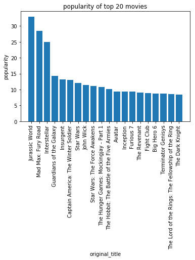

```python
df_31 = movie_data_drop.sort_values(by='popularity', ascending=False)[['original_title', 'popularity']].iloc[0:20, :]
df_31
plt.bar(df_31.original_title, df_31.popularity);
plt.title('popularity of top 20 movies')
plt.xlabel('original_title')
plt.ylabel('popularity')
plt.xticks(rotation=90);
```

**任务3.2：**分析电影净利润（票房-成本）随着年份变化的情况，并简单进行分析。

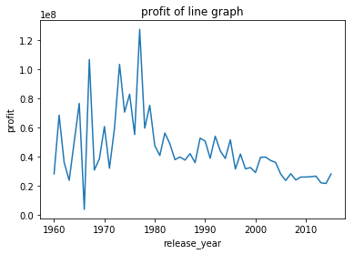

```python
df_32 = movie_data_drop[['release_year', 'budget_adj', 'revenue_adj']].groupby('release_year', as_index=False)[['budget_adj', 'revenue_adj']].mean().eval('profit = revenue_adj - budget_adj')
df_32
plt.errorbar(data=df_32, x='release_year', y='profit');
plt.title('profit of line graph')
plt.xlabel('release_year')
plt.ylabel('profit');
# 说明：在1980年前，电影的利润比较高，同时每年的利润波动也比较大；1980年后，电影的利润震荡收窄，同时利润逐年走低。
```

```python
# directors = movie_data_drop['director'].value_counts().sort_values(ascending=False)[:10].index
directors = movie_data_drop.groupby('director').count()['id'].sort_values(ascending=False)[:10].index
directors
df_33 = movie_data_drop[movie_data_drop['director'].isin(directors)][['popularity', 'original_title', 'director', 'revenue_adj']]
df_33
df_33['group_sort']=df_33['popularity'].groupby(df_33['director']).rank(ascending=0,method='dense')
df_33_v1 = df_33.sort_values(by='group_sort').head(30)
df_33_v1
# 数据获取到了，但是不知道如何展现，麻烦老师指导一下
```

|  | popularity | original_title | director | revenue_adj | group_sort |
| --- | --- | --- | --- | --- | --- |
| 7 | 7.667400 | The Martian | Ridley Scott | 5.477497e+08 | 1.0 |
| 3429 | 1.367727 | Midnight in Paris | Woody Allen | 1.464947e+08 | 1.0 |
| 8458 | 3.293387 | Mission: Impossible | Brian De Palma | 6.362971e+08 | 1.0 |
| 5236 | 2.604799 | Batman & Robin | Joel Schumacher | 3.235949e+08 | 1.0 |
| 2641 | 2.642249 | Ocean's Eleven | Steven Soderbergh | 5.550528e+08 | 1.0 |
| 5428 | 4.877927 | The Wolf of Wall Street | Martin Scorsese | 3.669257e+08 | 1.0 |
| 8375 | 4.578300 | Raiders of the Lost Ark | Steven Spielberg | 9.351169e+08 | 1.0 |
| 7891 | 1.331432 | A Nightmare on Elm Street | Wes Craven | 5.353504e+07 | 1.0 |
| 6558 | 3.655536 | The Da Vinci Code | Ron Howard | 8.201647e+08 | 1.0 |
| 657 | 3.863074 | American Sniper | Clint Eastwood | 4.995145e+08 | 1.0 |
| 8082 | 1.593740 | Batman Forever | Joel Schumacher | 4.815621e+08 | 2.0 |
| 7988 | 3.178818 | Scarface | Brian De Palma | 1.442422e+08 | 2.0 |
| 7825 | 4.935897 | Alien | Ridley Scott | 3.152733e+08 | 2.0 |
| 8475 | 1.286189 | Scream | Wes Craven | 2.405724e+08 | 2.0 |
| 8663 | 2.977558 | How the Grinch Stole Christmas | Ron Howard | 4.370498e+08 | 2.0 |
| 2888 | 2.245306 | Gran Torino | Clint Eastwood | 2.734101e+08 | 2.0 |
| 1927 | 3.176169 | Shutter Island | Martin Scorsese | 2.948042e+08 | 2.0 |
| 6980 | 2.175284 | Ocean's Twelve | Steven Soderbergh | 4.187685e+08 | 2.0 |
| 1332 | 1.179653 | Annie Hall | Woody Allen | 1.376203e+08 | 2.0 |
| 33 | 3.648210 | Bridge of Spies | Steven Spielberg | 1.496016e+08 | 2.0 |
| 1401 | 2.841562 | Angels & Demons | Ron Howard | 3.624621e+08 | 3.0 |
| 4391 | 1.974672 | Magic Mike | Steven Soderbergh | 1.588177e+08 | 3.0 |
| 8661 | 4.271452 | Gladiator | Ridley Scott | 5.795065e+08 | 3.0 |
| 5259 | 1.109101 | Scream 2 | Wes Craven | 2.341487e+08 | 3.0 |
| 7419 | 1.591827 | The Number 23 | Joel Schumacher | 8.157458e+07 | 3.0 |
| 9180 | 3.536655 | Indiana Jones and the Last Crusade | Steven Spielberg | 8.340611e+08 | 3.0 |
| 10175 | 1.263483 | Carrie | Brian De Palma | 1.295114e+08 | 3.0 |
| 6248 | 1.051177 | Match Point | Woody Allen | 9.524997e+07 | 3.0 |
| 6563 | 2.819750 | The Departed | Martin Scorsese | 3.135189e+08 | 3.0 |
| 6990 | 1.648554 | Million Dollar Baby | Clint Eastwood | 2.502418e+08 | 3.0 |

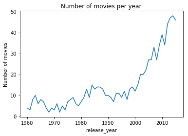

```python
df_34 = movie_data_drop[['release_date', 'release_year']]
df_34['release_date'] = df_34['release_date'].apply(lambda x:x.split('/')[0])
df_34 = df_34.query('release_date == "6"').groupby('release_year', as_index=False).count()
plt.errorbar(data=df_34, x='release_year', y='release_date');
plt.title('Number of movies per year')
plt.xlabel('release_year')
plt.ylabel('Number of movies');
# 电影数量在2000年前比较平稳；在2000年后，有飞速的增长
```

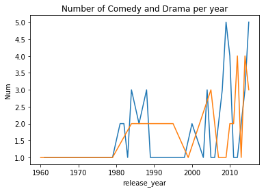

```python
df_35 = movie_data_drop[['genres', 'release_date', 'release_year']]
df_35['release_date'] = df_35['release_date'].apply(lambda x:x.split('/')[0])
df_35 = df_35.query('release_date == "6"').query('genres in ["Comedy","Drama"]')
df_35
df_35_Comedy = df_35.query('genres == "Comedy"')
df_35_Comedy = df_35_Comedy.groupby('release_year', as_index=False).count()
df_35_Drama = df_35.query('genres == "Drama"')
df_35_Drama = df_35_Drama.groupby('release_year', as_index=False).count()

plt.errorbar(data=df_35_Comedy, x='release_year', y='genres');
plt.errorbar(data=df_35_Drama, x='release_year', y='genres');
plt.title('Number of Comedy and Drama per year')
plt.xlabel('release_year')
plt.ylabel('Num');
```

> 注意: 当你写完了所有的代码，并且回答了所有的问题。你就可以把你的 iPython Notebook 导出成 HTML 文件。你可以在菜单栏，这样导出**File -> Download as -> HTML (.html)、Python (.py)** 把导出的 HTML、python文件 和这个 iPython notebook 一起提交给审阅者。